# Exercises Day 1 Part 2- Greesham Simon

2019-09-18

## ## Load the data

Load the `gapminder` dataset.

```r
library(here)
gapminder <- read.csv(here("data/gapminder5.csv"),
                      stringsAsFactors=FALSE)
```

## ## If Statement

Use an if() statement to print a suitable message reporting whether there are any records from 2002 in the gapminder dataset. Now do the same for 2012.

Hint: use the any function.

```r
test_year<- 2002
if(any(gapminder$year == test_year)){
    cat("There are records from",test_year,"in the gapminder dataset.")
} else{
    cat("There aren't any records from",test_year,"in the gapminder dataset.")
}
```

```
## There are records from 2002 in the gapminder dataset.
```

```r
test_year<- 2012
if(any(gapminder$year == test_year)){
    cat("There are records from",test_year,"in the gapminder dataset.")
} else{
    cat("There aren't any records from",test_year,"in the gapminder dataset.")
}
```

```
## There aren't any records from 2012 in the gapminder dataset.
```

## ## Loop and If Statement

Write a script that finds the mean life expectancy by country for countries whose population is below the mean for the dataset

Write a script that loops through the gapminder data by continent and prints out whether the mean life expectancy is smaller than 50, between 50 and 70, or greater than 70.

```r
mean_pop<- mean(gapminder$pop)

for(i in unique(gapminder$country)) {
    country_mean <- mean(gapminder$pop[gapminder$country==i])

    if (country_mean < mean_pop) {
        cat("\nMean life expectancy for",i," is",mean(gapminder$lifeExp[gapminder$country == i]),".")
    }
}
```

```
##
## Mean life expectancy for Afghanistan  is 37.47883 .
## Mean life expectancy for Albania  is 68.43292 .
## Mean life expectancy for Algeria  is 59.03017 .
## Mean life expectancy for Angola  is 37.8835 .
## Mean life expectancy for Argentina  is 69.06042 .
## Mean life expectancy for Australia  is 74.66292 .
## Mean life expectancy for Austria  is 73.10325 .
## Mean life expectancy for Bahrain  is 65.60567 .
## Mean life expectancy for Belgium  is 73.64175 .
## Mean life expectancy for Benin  is 48.77992 .
## Mean life expectancy for Bolivia  is 52.50458 .
## Mean life expectancy for Bosnia and Herzegovina  is 67.70783 .
## Mean life expectancy for Botswana  is 54.5975 .
## Mean life expectancy for Bulgaria  is 69.74375 .
## Mean life expectancy for Burkina Faso  is 44.694 .
## Mean life expectancy for Burundi  is 44.81733 .
## Mean life expectancy for Cambodia  is 47.90275 .
## Mean life expectancy for Cameroon  is 48.1285 .
## Mean life expectancy for Canada  is 74.90275 .
## Mean life expectancy for Central African Republic  is 43.86692 .
## Mean life expectancy for Chad  is 46.77358 .
## Mean life expectancy for Chile  is 67.43092 .
## Mean life expectancy for Colombia  is 63.89775 .
## Mean life expectancy for Comoros  is 52.38175 .
## Mean life expectancy for Congo Rep.  is 52.50192 .
## Mean life expectancy for Costa Rica  is 70.18142 .
## Mean life expectancy for Cote d'Ivoire  is 48.43617 .
## Mean life expectancy for Croatia  is 70.05592 .
## Mean life expectancy for Cuba  is 71.04508 .
## Mean life expectancy for Czech Republic  is 71.5105 .
## Mean life expectancy for Denmark  is 74.37017 .
## Mean life expectancy for Djibouti  is 46.38075 .
## Mean life expectancy for Dominican Republic  is 61.5545 .
## Mean life expectancy for Ecuador  is 62.81683 .
## Mean life expectancy for El Salvador  is 59.63333 .
## Mean life expectancy for Equatorial Guinea  is 42.96 .
## Mean life expectancy for Eritrea  is 45.99925 .
## Mean life expectancy for Finland  is 72.99192 .
## Mean life expectancy for Gabon  is 51.2205 .
```

[output cut: 61 more lines]

```
## Mean life expectancy for Sweden  is 76.177 .
## Mean life expectancy for Switzerland  is 75.56508 .
## Mean life expectancy for Syria  is 61.34617 .
## Mean life expectancy for Taiwan  is 70.33667 .
## Mean life expectancy for Tanzania  is 47.91233 .
## Mean life expectancy for Togo  is 51.49875 .
## Mean life expectancy for Trinidad and Tobago  is 66.828 .
## Mean life expectancy for Tunisia  is 60.721 .
## Mean life expectancy for Uganda  is 47.61883 .
## Mean life expectancy for Uruguay  is 70.78158 .
## Mean life expectancy for Venezuela  is 66.58067 .
## Mean life expectancy for West Bank and Gaza  is 60.32867 .
## Mean life expectancy for Yemen Rep.  is 46.78042 .
## Mean life expectancy for Zambia  is 45.99633 .
## Mean life expectancy for Zimbabwe  is 52.66317 .
```

```r
lowLim <- 50
highLim <-70

continents <- unique(gapminder$continent)

for(i in continents){
    tmp <- mean(gapminder$lifeExp[gapminder$continent==i])
    if (tmp< lowLim) {
        cat(sep="","\nContinent ", i," has a mean life expectancy below ", lowLim,"." )
    } else if (tmp > highLim){
         cat(sep="","\nContinent ", i," has a mean life expectancy above ", highLim,"." )
    } else {
         cat(sep="","\nContinent ", i," has a mean life expectancy between ", lowLim," and ", highLim, "." )
    }
}
```

```
##
## Continent Asia has a mean life expectancy between 50 and 70.
## Continent Europe has a mean life expectancy above 70.
## Continent Africa has a mean life expectancy below 50.
## Continent Americas has a mean life expectancy between 50 and 70.
## Continent Oceania has a mean life expectancy above 70.
```

## ## Exercise: Write Functions

Create a function that given a data frame will print the name of each column and the class of data it contains. Use the gapminder dataset. Hint: Use mode() or class() to get the class of the data in each column. Remember that names() or colnames() returns the name of the columns in a dataset.

Create a function that given a vector will print the mean and the standard deviation of a vector, it will optionally also print the median. Hint: include an argument that takes a boolean (TRUE/FALSE) operator and then include an if statement.

```r
#first function prints name of each column and class

colNamesClass<- function(df) {
    cols <-names(df)
    for (i in cols){
        cat("\n",i,":",class(df[[i]]))
    }
}

colNamesClass(gapminder)
```

```
##
##  country : character
##  year : integer
##  pop : numeric
##  continent : character
##  lifeExp : numeric
##  gdpPercap : numeric
```

```r
#second function prints mean and standard deviation. It may print median if printMedian is set to True

vectorBasicInfo <- function(x, printMedian=FALSE){
    cat("Mean:",mean(x),"\nStandard Deviation:",sd(x))
    if (printMedian){
        cat("\nMedian:", median(x))
    }
}

vectorBasicInfo(gapminder$lifeExp)
```

```
## Mean: 59.47444
## Standard Deviation: 12.91711
```

```r
vectorBasicInfo(gapminder$lifeExp, TRUE)
```

```
## Mean: 59.47444
## Standard Deviation: 12.91711
## Median: 60.7125
```

## ## Exercise: Analyzing the Relationship

Use what you???ve learned so far to answer the following questions using the gapminder dataset. Be sure to include some visualizations!

1. What is the relationship between GDP per capita and life expectancy? Does this relationship change over time? (Hint: Use the natural log of both variables.)
2. Does the relationship between GDP per capita and life expectacy vary by continent? Make sure you divide the Americas into North and South America.

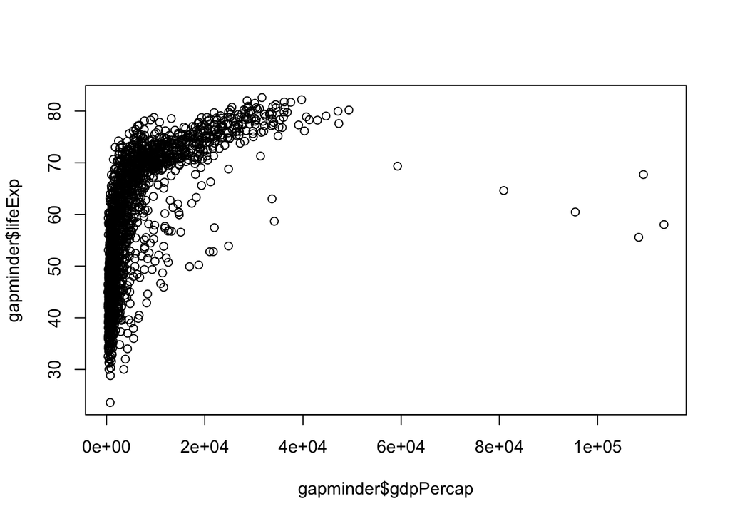

```r
#Problem 1
#look at initial plot
plot(x=gapminder$gdpPercap,y=gapminder$lifeExp)
```

```r
#look at transformed plot (nat log)
plot(x=log(gapminder$gdpPercap),y=log(gapminder$lifeExp))

linModel<- lm(log(gapminder$lifeExp)~log(gapminder$gdpPercap))
summary(linModel)
```

[output not shown]

```
##
## Call:
## lm(formula = log(gapminder$lifeExp) ~ log(gapminder$gdpPercap))
##
## Residuals:
##      Min       1Q   Median       3Q      Max
## -0.67059 -0.06453  0.01978  0.09086  0.36156
##
## Coefficients:
##                          Estimate Std. Error t value Pr(>|t|)
## (Intercept)              2.864177   0.023283  123.02   <2e-16 ***
## log(gapminder$gdpPercap) 0.146549   0.002821   51.95   <2e-16 ***
## ---
## Signif. codes:  0 '***' 0.001 '**' 0.01 '*' 0.05 '.' 0.1 ' ' 1
##
## Residual standard error: 0.1445 on 1702 degrees of freedom
## Multiple R-squared:  0.6132, Adjusted R-squared:  0.613
## F-statistic:  2698 on 1 and 1702 DF,  p-value: < 2.2e-16
```

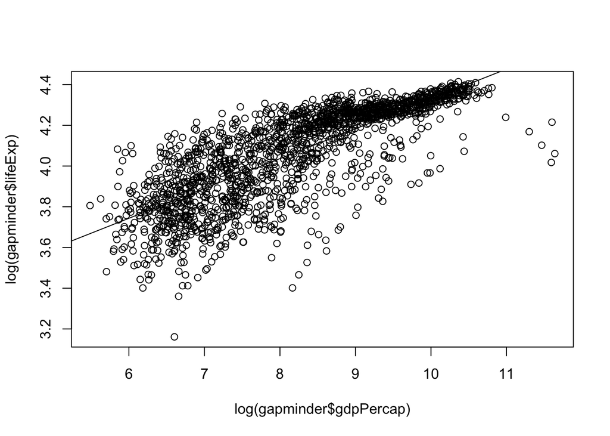

```r
plot(x=log(gapminder$gdpPercap),y=log(gapminder$lifeExp))
abline(a=linModel$coefficients[1], b=linModel$coefficients[2])
```

```r
# the power model looks like a good fit between life expectancy and gdp per capita


#Problem 2
# identify the countries in the continent Americas
unique(gapminder$country[gapminder$continent=="Americas"])
```

```
##  [1] "Argentina"           "Bolivia"             "Brazil"
##  [4] "Canada"              "Chile"               "Colombia"
##  [7] "Costa Rica"          "Cuba"                "Dominican Republic"
## [10] "Ecuador"             "El Salvador"         "Guatemala"
## [13] "Haiti"               "Honduras"            "Jamaica"
## [16] "Mexico"              "Nicaragua"           "Panama"
## [19] "Paraguay"            "Peru"                "Puerto Rico"
## [22] "Trinidad and Tobago" "United States"       "Uruguay"
## [25] "Venezuela"
```

```r
#Create vector of North American countries
nAmerica <- c("Canada", "Costa Rica","Cuba","Dominican Republic","El Salvador","Guatemala","Hait","Honduras","Jamaica", "Mexica", "Nicaragua", "Panama", "Trinidad and Tobago", "United States")


#Create New Continent column in gapminder
gapminder$NewCont <- gapminder$continent

#Parses through each column and assigns N America to North American countries and South America to the other "Americas" countries
for (i in 1:length(gapminder$NewCont)){
    if(gapminder$NewCont[i] == "Americas"){
        if(gapminder$country[i] %in% nAmerica){
            gapminder$NewCont[i] <- "North America"
        } else{
            gapminder$NewCont[i] <- "South America"
        }
    }

}

continents_new <- unique(gapminder$NewCon)
gapminder$logLifeExp <- log(gapminder$lifeExp)
gapminder$loggdpPerCap <- log(gapminder$gdpPercap)

for (i in continents_new){
    lm_ex <- lm(gapminder$logLifeExp[gapminder$NewCont==i]~ gapminder$loggdpPerCap[gapminder$NewCont==i])

    cat("\n", i, ": intercept=", lm_ex$coefficients[1],", slope=", lm_ex$coefficients[2])

}
```

```
##
##  Asia : intercept= 3.195569 , slope= 0.1088043
##  Europe : intercept= 3.415953 , slope= 0.09163567
##  Africa : intercept= 3.070048 , slope= 0.1106305
##  South America : intercept= 2.5515 , slope= 0.1859074
##  Oceania : intercept= 2.882798 , slope= 0.145673
##  North America : intercept= 2.987538 , slope= 0.136676
```